# Schelling

CC&PC

Summer School

## Schelling Segregation Model

Here are some code lines to prepare the simulation of Schelling’s Model of spatial segregation. We start by the environment.

### Environment

From now on , the environment is a static square grid of `size` * `size` cells, filled at a given percentage `pctOccupied` of householder agents.

A cell can contain only one householder.

Each householder belongs to one of two groups (for now), denoted by values (here : 1 and 2).

Basic Schelling model suggest that agents is randomly affected to one groupe or the other (50% of chance), yet we write the code as if it could change.

From the R code point of view, the environment grid is easier to consider as a matrix, even if it will be soon transformed in a long format data table, moreconvenient for `dplyr` library functions.

At a given location (i,j), the value of the cell will be either `NA` (empty cell), 1 (Red household), or 2 (Blue houshold).

At initialization, households are randomly located in the grid by sampling (without replacement) positions.

Household groups are then determined randomly : the cell value is chosen between 1 and 2 (this time with replacement) using `pctRed` and `pctBlue` as probabilities weights.

```r
matrixSchellingState <-  function(size, pctOccupied=.5, pctRed=0.5, pctBlue=1-pctRed ){

  matrixState <- matrix(NA,size,size)
  nbAgents <- floor(pctOccupied * size^2)
  householdCells <- sample(size ^ 2, nbAgents)
  matrixState[householdCells] <-  sample(c(1,2), nbAgents, replace = T, prob = c(pctRed,pctBlue))
  return(matrixState)
}
matrixState <-  matrixSchellingState(40,0.5,0.5, 0.5)
```

Now that the sate has been defined, we will code the `display` function, to actually see something.

## Display

### Data Format

Display uses the **ggplot** library, a widely used library, with so fancy graphic renderings it seems impossible not to use it.

To that extent, the state data structure has to be tweaked a little bit. ggplot2 needs a data structure where each line is an individual i.e. a piece of data, formed as follows:

```
     | Var1 | Var2 |    Var3  |
|----|------|------|----------|
|row1| 20   | 12.4 | "Batman" |
|row2|  8   | 3.5  | "Robin"  |
```

in our case, pieces of data are householders, located in the grid by their coordinates (`Xcoord,Ycoord`), belonging to a group (`value`); so we need something like:

```
      | Xcoord | Ycoord | Group |
          ⋮       ⋮       ⋮
row_n |   24   |   75   |   2   |
          ⋮       ⋮       ⋮
row_p |   58   |    8   |   1   |
```

Starting from a matrix structure, this transformation is done by the `melt` function of `reshape` library.

```r
meltedState <- melt(matrixState, varnames = c("X","Y"))
head(meltedState,10)  #to see what it looks like and get the column names
```

```
##     X Y value
## 1   1 1     1
## 2   2 1     2
## 3   3 1    NA
## 4   4 1     2
## 5   5 1     2
## 6   6 1     2
## 7   7 1     1
## 8   8 1    NA
## 9   9 1    NA
## 10 10 1     1
```

### Display as raster

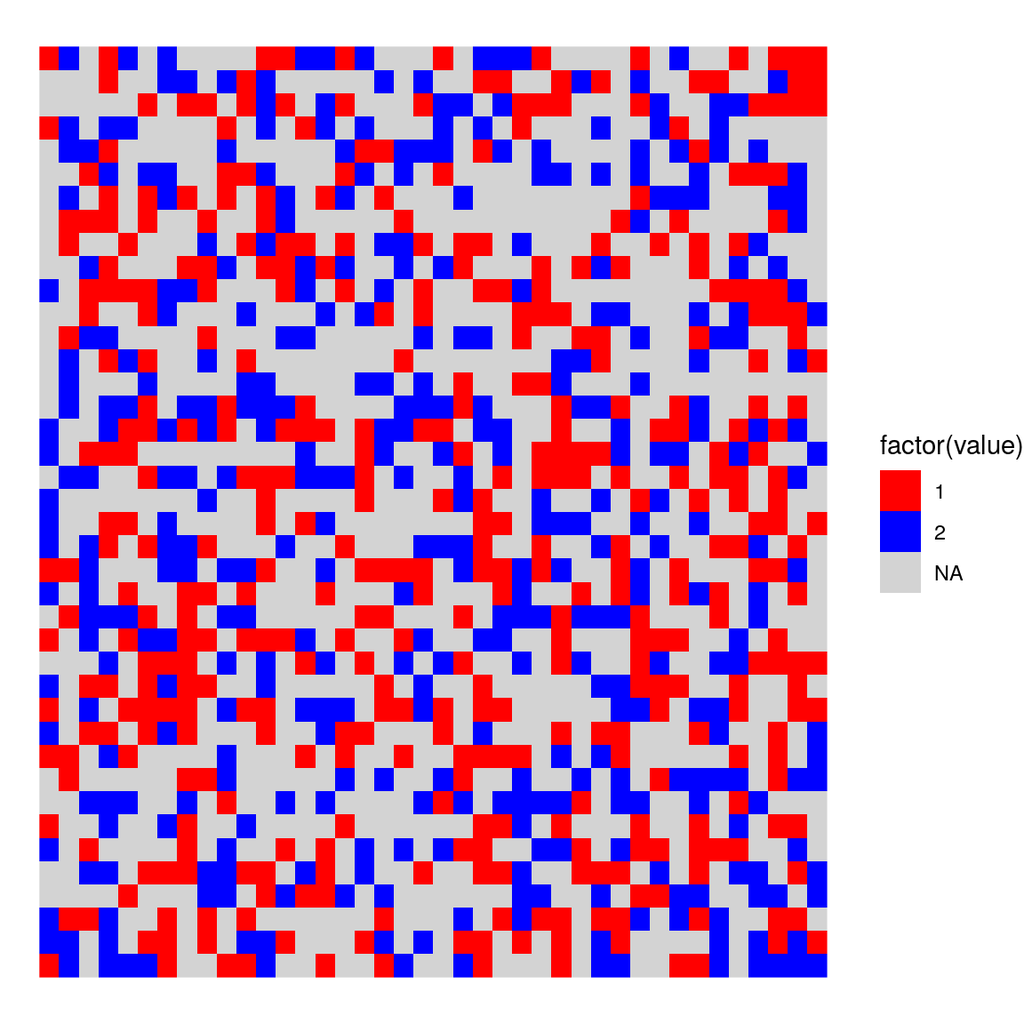

```r
# color definitions
colorMapping <- c("1"="red", "2"="blue")

myggplot <- ggplot(meltedState, aes(x=X, y=Y)) +
  geom_raster(aes(fill=factor(value)))+
 scale_fill_manual(values = colorMapping, na.value="lightgrey")+
  theme_void()
myggplot
```

this does the job, yet we can improve rendering by drawing household in cells as points, in a scattermap-like way:

### Display as scatterplot

`ggplot` will whine because of the NA values of empty cells, you can ignore the warnings.

```
## Warning: Removed 800 rows containing missing values (geom_point).
```

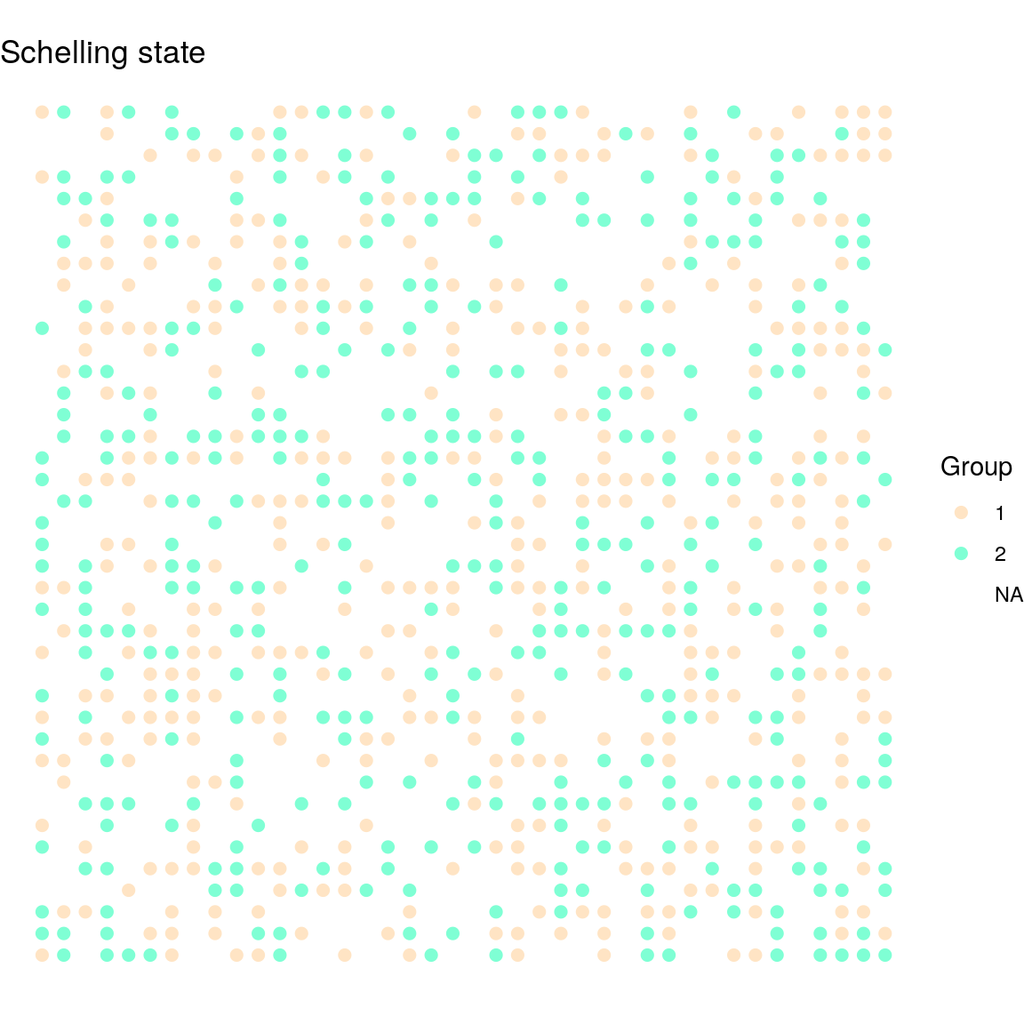

```r
# color definitions
fancyColors <- c("1"="bisque", "2"="aquamarine")

myggplot2 <- ggplot(meltedState, aes(x=X, y=Y)) +
  geom_point(size=2, aes(colour=factor(value)))+ #size has to be adjusted regarding the size of the state
 scale_color_manual( values=fancyColors, name="Group" )+
  theme_void()+
  coord_fixed(ratio = 1) +
  ggtitle("Schelling state")

myggplot2
```

```r
#save as a function for later use
displayState <- function(mystate, dotSize=1){
 myggplot2 <- ggplot(mystate, aes(x=X, y=Y)) +
  geom_point(size=dotSize, aes(colour=factor(value)))+ #size has to be adjusted regarding the size of the state
 scale_color_manual( values=fancyColors, name="Group" )+
  theme_void()+
  coord_fixed(ratio = 1) +
  ggtitle("Schelling state")
  return(myggplot2)
}
```

## Dynamics

At each simulation step, each agent :

1. looks around and establish the proportion of similar householder in its (Moore) nieghborhood
2. if this proportion is below the threshold → looks for another place where the proportion is above , remains in place otherwise.

To achieve this beahavior , we need a way to figure out :

### Getting the neighborhood

We will start with the Moore neighborhood (the 8 adjacents cells of a cell) ; this defintion could be extended in a later version.

Given a coordinate (i,j) the neighborhood is given by the following code. The `meAndMyNeighbors(i,j)` select the neighboring portion of the (i,j) cell in the `state` . The `getgetneighbors(i,j)` transforms this portion in a more convenient format (a list) and excludes the calling cell (i,j) Special cases of corner and border cells are considered having incomplete neighborhood.

```r
#to ensure the call to filter function is calling the dplyr version
filter = dplyr::filter

meAndMyNeighbors <- function (state,i,j) {
  #this version doesn't suppose a square world, but a 9 Moore neighborhod
  neigh <-   filter(state, between(X,i-1,i+1) & between(Y,j-1,j+1) & !is.na(value))
  return(neigh)
}


getneighbors <- function(state, i,j){
    neighborhood <- meAndMyNeighbors(state, i, j)
    #exclude the caller cell
    neighborhood <- neighborhood[!(neighborhood$X==i & neighborhood$Y==j),]
  return(neighborhood)
}
```

### Evaluating cells “happiness”

Now we need to evaluate if the householder of a cell (i,j) is satisfied by its neighborhood , i.e. if the proportion of householders of another group around him is below the `tolerance` threshold.

```r
tolerance <- 0.3

isHappy <- function(state, i , j, tolerance){
  cell <-  filter(state, X==i & Y==j)
  if (is.na(cell$value)){return(NA)}
  neigh <- getneighbors(state,i,j)
  numberOfDiff <-sum(cell$value!=neigh$value, na.rm = T)
  happy <-  (numberOfDiff / nrow(neigh) ) < tolerance
  return(happy)
}
```

We now create a test environment and apply the function `isHappy` to each cell.

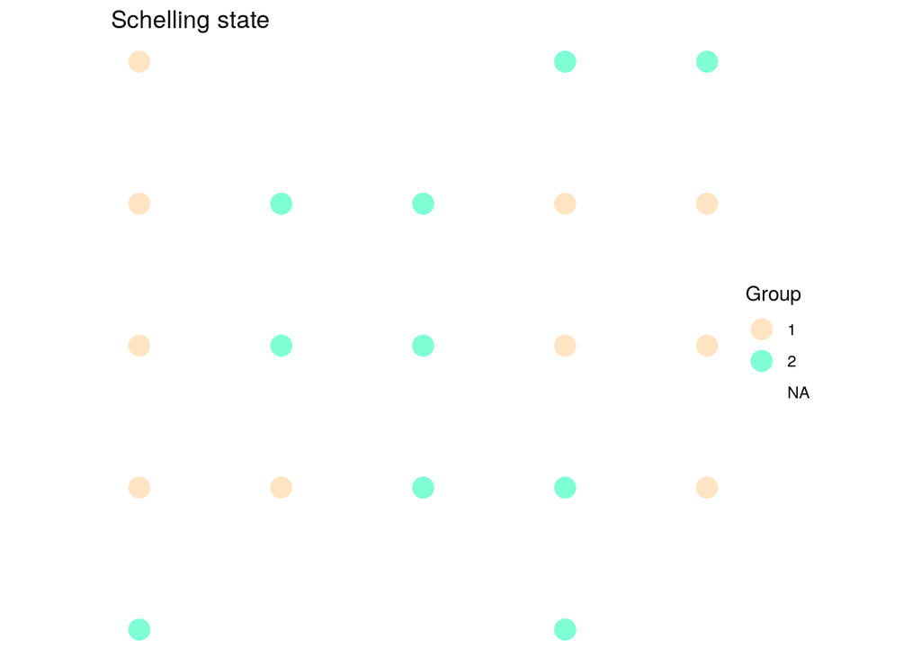

```r
testEnv <-  matrixSchellingState(5,pctOccupied = 0.8)
meltTestEnv <-  melt(testEnv,varnames = c("X","Y"))
displayState(meltTestEnv, dotSize = 5)
```

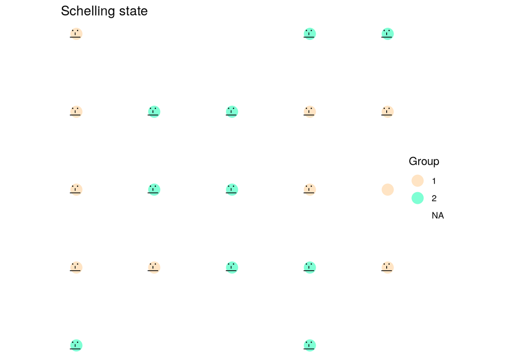

```r
#we apply the function isHappy to create a newcolumn of happiness in the state
meltTestEnv <- meltTestEnv %>% rowwise() %>% mutate(happy= isHappy(., X, Y, tolerance = 0.3))


# we update the display function code to display unhappiness
displayStateUnhappy <- function(meltedState){
  pp <- displayState(meltedState, dotSize = 5) +
    geom_text(data = subset(meltedState, !happy ), aes(X,Y,label = ":-|"), angle=-90)
return(pp)
  }
displayStateUnhappy(meltTestEnv)
```

```r
# save as function for later
updateHappiness <- function(state, tolerance){
  state <- state %>% rowwise() %>% mutate(happy= isHappy(., X, Y, tolerance ))
}

getUnhappy <-  function(state){
  return(filter(state, !happy))
}
#melted state constructor
createMeltedSchellingState <- function(size, pctOccupied=.5, pctRed=0.5, pctBlue=1-pctRed, tolerance){
  matState <-  matrixSchellingState(size, pctOccupied, pctRed, pctBlue)
  # Warning : melt destroy attr
  meltedState <-  melt(matState,varnames = c("X","Y"))
  meltedState$happy <-  NA
      meltedState <-  updateHappiness(meltedState, tolerance  )
  # we add an explicit ID of cells (row number), it will be useful
  meltedState$ID <- seq.int(nrow(meltedState))
  return(meltedState)
}
```

### Getting empty cells

Unsatisfied householders look for empty cells to relocate to. In our model, empty cells have a `NA`value. We create and maintain a subset of our meltedState, keeping track of the empty cells.

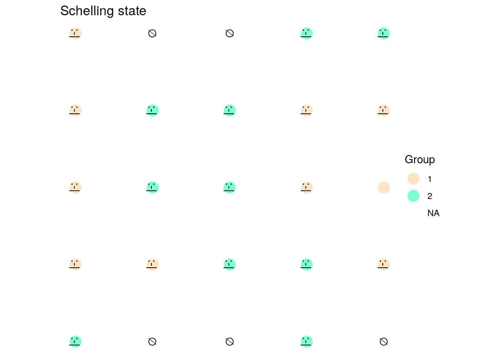

```r
getEmptyCells <-  function(state){
  return(state %>%filter(is.na(value))  )
}
emptyCells <-  getEmptyCells(meltTestEnv)

#we add a symbol layer  to check emptyness correction  visually
pp <-  displayStateUnhappy(meltTestEnv) +
  geom_text(data = subset(meltTestEnv, is.na(value) ), aes(X,Y,label = sprintf("\U2205")), angle=-90)
pp
```

### Moving to more satisfying locations

The idea is now to move unhappy households to another, empty location . For each householder, an empty location/cell is randomly drawn, and the householder moves in it .

We sample among empty cells, update these empty cells values according to unhappy householders values, and put the previous unhappy householders cells to`NA` (i.e. empty)

We start by moving householders one at a time, via the `moveOne` function.

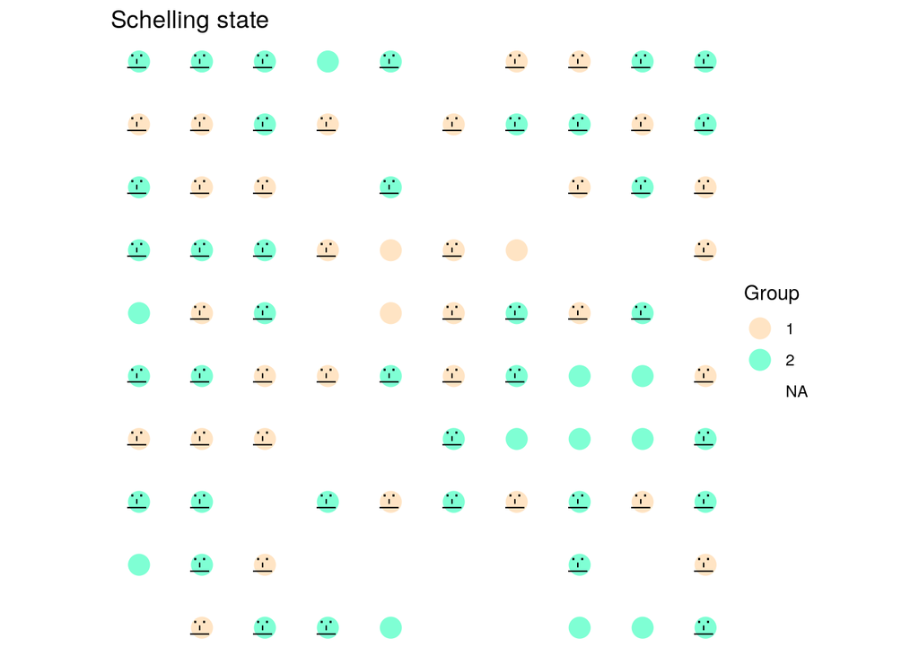

```r
#we create another test environemment and get rid of the previous
rm(meltTestEnv)
stateEnv <- createMeltedSchellingState(size = 10,pctOccupied = 0.8, tolerance=0.3)

displayStateUnhappy(stateEnv)
```

```r
unhappy <-  getUnhappy(stateEnv)
numberOfUnHappy <-  nrow(unhappy)
emptyCells <-  getEmptyCells(stateEnv)
numberOfEmpty <-  nrow(emptyCells)
cat(numberOfEmpty , "\n") # has to be 20% of state size squared since pctOccupied is 80%
```

```
## 20
```

```r
moveOne <-  function(state, tolerance, followMover=F){
  #take one unhappy householder among unhappyhousholders
  unhappyHHs <-  getUnhappy(state)
  uhhh <- sample_n(unhappyHHs, 1)
  emptyCells <-  getEmptyCells(state)
  emptyCell <-  sample_n(emptyCells,1)

  if (followMover){
  pp <-  displayStateUnhappy(state)+
    geom_point(data = filter(state, ID==uhhh$ID ), aes(X,Y),color="red", size = 8)+
    geom_point(data = filter(state, ID==emptyCell$ID ), aes(X,Y),color="green", size = 8)

  print(pp)
}

  #State has to be updated by swapping values of these two cells , ID is useful here
   state[state$ID==emptyCell$ID,"value"] <- uhhh$value
  state[state$ID==uhhh$ID,"value"] <- emptyCell$value

  #moving changes happiness, so we update the state
  state <-  updateHappiness(state, tolerance )

    return(state)
}
```

Botice that **all** the state is updated after each move, that does the job , but perform a lot of useless updates since a vast majority of the state is not affected by the move of *one* householder.

To check the dynamic , we consider 3 plots. First one is state before we move one householder. Next plot show the sampled householder with a red circle, and its destination(empty cell) with a green one. Moving happens, and the final plot show the state afterwards

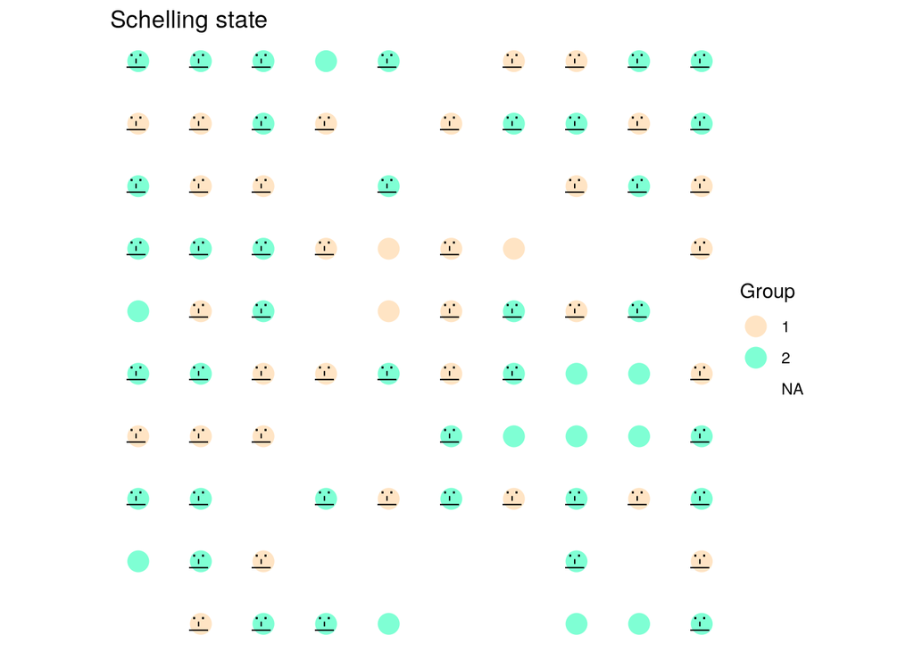

```r
displayStateUnhappy(stateEnv)
```

```r
stateEnv <- moveOne(stateEnv, 0.3, followMover = T)
```

[figure not shown]

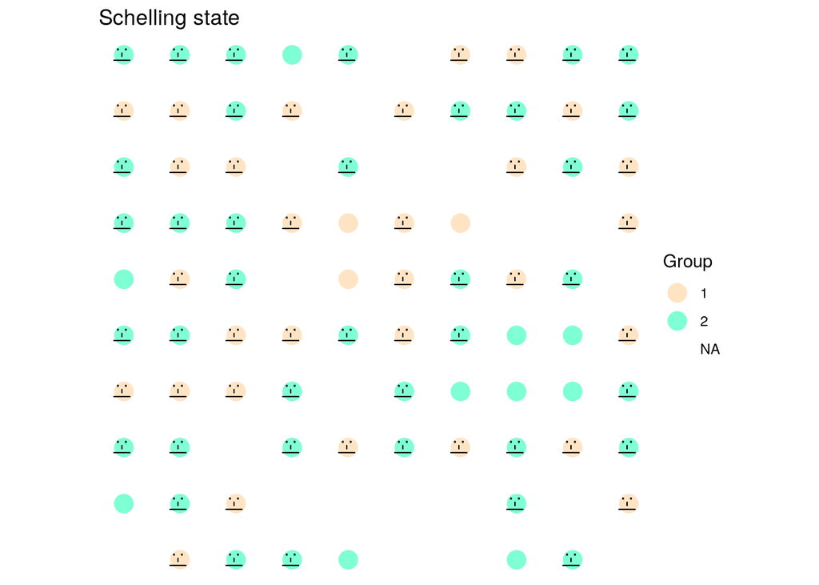

```r
displayStateUnhappy(stateEnv)
```

## Simulation Loop

Now that we have implemented one step of the model Dynamic , we can automate its execution in a loop.

```r
simulate <-  function(steps, state, tolerance){
  for (i in 1:steps){

        if (i %% 10 ==0) {
      cat("step : ", i , "\n")
    }

    if (nrow(getUnhappy(state)) == 0){
      cat("Everybody is fine with their location\n")
      break
    }
    state <- moveOne(state,tolerance)

  }
  return(state)
}
```

Basically a simulation loop is a loop that repeat a simulation step a certain number of times or until a certain condition is reached. Here we chose to execute simulation steps a certain number of times (and do nothing in case everyone is happy)

## Example of experiment workflow

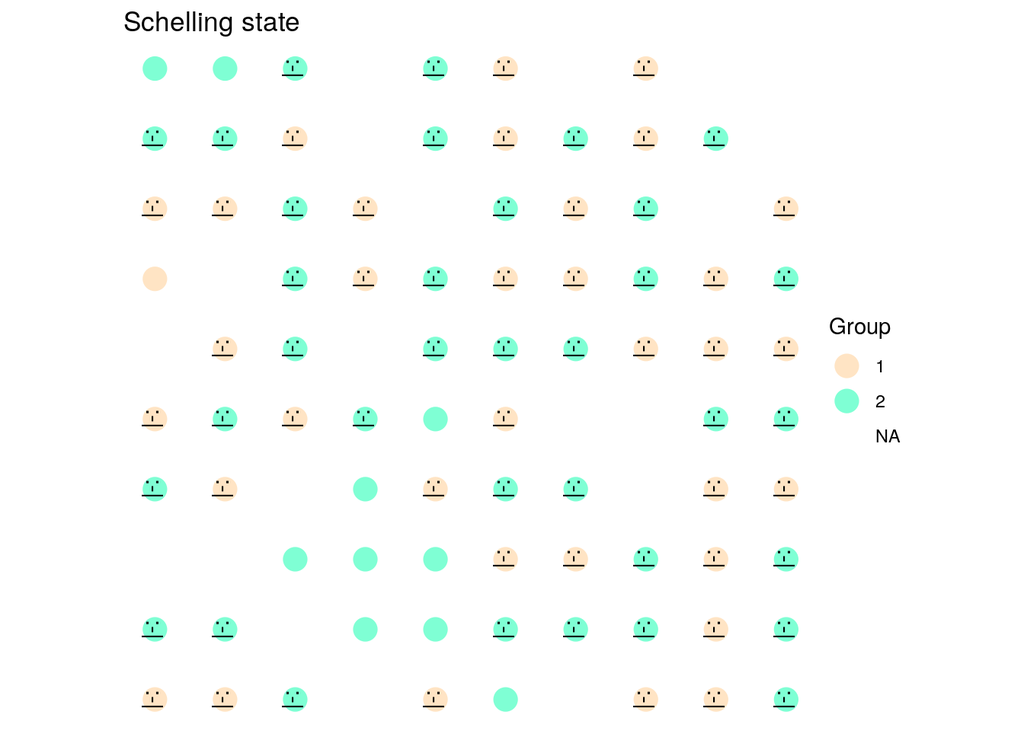

```r
myExpTolerance <-  0.3
s <-  createMeltedSchellingState(10,pctOccupied = 0.8,pctRed = 0.5, pctBlue = 0.5, tolerance= myExpTolerance)
displayStateUnhappy(s)
```

```r
nrow(getUnhappy(s))
```

```
## [1] 69
```

```r
s <-  simulate(steps= 200, state=s, tolerance = myExpTolerance)
```

```
## step :  10
## step :  20
## step :  30
## step :  40
## step :  50
## step :  60
## step :  70
## step :  80
## step :  90
## step :  100
## step :  110
## step :  120
## step :  130
## step :  140
## step :  150
## step :  160
## step :  170
## step :  180
## step :  190
## step :  200
```

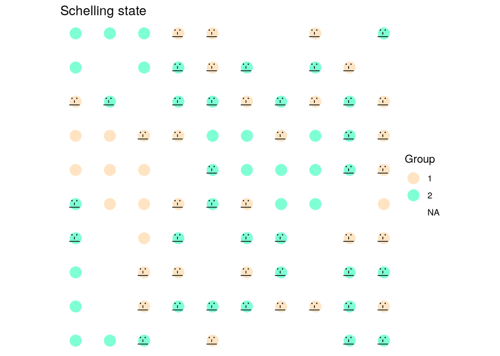

```r
displayStateUnhappy(s)
```

```r
nrow(getUnhappy(s))
```

```
## [1] 54
```

This is loooooooooog . See at the end of the document why , and how to speed it up !

# Measures

## Global Similarity percentage

Global similarity is the aggregated (or averaged) ratio between similar neighbors and neighbors. On perfect segregation, it should be of 100%.

```r
getSimilarNeighborsNumber <-  function(state, i, j){
  #cell <-  filter(state, X==i & Y==j)
  cell <-  state[state$X==i & state$Y==j, ]
  neigh <- getneighbors(state,i,j)
  numberOfSimilar <-sum(cell$value==neigh$value, na.rm = T)
return(numberOfSimilar)
    }


globalSimilarityPct <-  function(state){
  res <-  state %>% rowwise() %>% transmute(nbSimNeigh = getSimilarNeighborsNumber(.,X,Y) , nbNeigh = nrow(getneighbors(.,X,Y)))

    return(sum(res$nbSimNeigh) / sum(res$nbNeigh))
}
globalSimilarityPct(stateEnv)
```

```
## [1] 0.3846154
```

## Global unsatisfaction percentage

```r
globalunHappyPct <-  function(state){
  populationSize  <-  nrow(state %>%  filter(!is.na(value)))
  sads <- nrow(state %>%  filter(!happy))
    return(sads/populationSize * 100)
}
globalunHappyPct(stateEnv)
```

```
## [1] 83.75
```

# Alterations

Since schelling’s segregation model is a simple model , a lot of *alterations* can be made :

- Choice of location criteria
- happiness evaluation
- neighborhood sizes
- number of groups
- emptiness of cells
- radius threshold when moving
- rates of moving

Some of them can be madfe by changing parameters values, most of them requires some new code writing.

More efficient code is available in the `moreEfficientSchelling.R`file, with a multigroup version.

For now we only show an optimization of the code in the `moveOne` function. For that we need helpers function to update the happyness of impacted househoulders after a move : their neighboorhood. These helper function are `meAndMyNeighborsByID`, `getneighborsByID` and `isHappyByID` , that use ID to “locate” householder in the state dataframe.

```r
meAndMyNeighborsByID <- function (id,state) {
  #only if id = nrow
  i <-  state[id,"X"]
  j <-  state[id,"Y"]
  #this version doesn't suppose a square world, but a 9 Moore neighborhod
  #neigh <-   filter(state, between(X,i-1,i+1) & between(Y,j-1,j+1) & !is.na(value))
  neigh <-   filter(state, between(X,i-1,i+1) & between(Y,j-1,j+1))

  return(neigh)
}


getneighborsByID <- function(id, state){
  neighborhood <- meAndMyNeighborsByID(id, state)
  #exclude the caller cell
  neighborhood <- neighborhood[neighborhood$ID !=id,]
  return(neighborhood)
}

isHappybyID <-  function(id, state, tolerance){
  cell <-  filter(state, ID==id)
  if (is.na(cell$value)){return(NA)}
  neigh <- getneighborsByID(id,state)
  numberOfDiff <-sum(cell$value!=neigh$value, na.rm = T)
  happy <-  (numberOfDiff / nrow(neigh) ) < tolerance
  return(happy)
}





moveOneFaster <-  function(state, tolerance, followMover=F){
  #take one unhappy householder
  unhappyHHs <-  getUnhappy(state)
  uhhh <- sample_n(unhappyHHs, 1)
  uhhhID <-  uhhh$ID
  uhhhvalue <-  uhhh$value
  emptyCells <-  getEmptyCells(state)
  oneEmptyCell <-  sample_n(emptyCells,1)
  emptyID <- oneEmptyCell$ID


  if (followMover){
    pp <-  displayStateUnhappy(state)+
      geom_point(data= uhhh, aes(X,Y),color="red", size = 8, alpha= 0.3)+
      geom_point(data = oneEmptyCell, aes(X,Y),color="green", size = 8, alpha=0.3)

    print(pp)
  }

  #State has to be updated  by swapping values of these two cells
  state[emptyID,"value"] <- uhhhvalue
  state[uhhhID,"value"] <- NA

  #origin cell is no longer happy or unhappy since it's empty
  state[uhhhID,"happy"] <- NA

  #moving changes happiness of the destination neighborhood, so we update it
  destNeigh <-  meAndMyNeighborsByID(id = emptyID,state)
  state[destNeigh$ID,"happy"] <-  sapply(destNeigh$ID, FUN = isHappybyID, state=state, tolerance)

  #state <-  updateHappiness(state, tolerance )
  return(state)
}




simulateFaster <-  function(steps, state, tolerance){
  for (i in 1:steps){
    if (i %% 200 ==0) {
      cat("step : ", i , "\n")
    }
    unhappy <-  getUnhappy(state)
    if (nrow(unhappy) == 0){
      cat("Everybody is fine with their location\n")
      break
    }
    state <- moveOneFaster(state,tolerance)
  }
    return(state)
}
```

Now we should increase the size of the state , simulate longer, and observe the result :

```r
myExpTolerance <-  0.3
s <-  createMeltedSchellingState(30,pctOccupied = 0.8,pctRed = 0.5, pctBlue = 0.5, tolerance= myExpTolerance)
displayStateUnhappy(s)
nrow(getUnhappy(s))
s <-  simulateFaster(steps= 800, state=s, tolerance = myExpTolerance)
displayStateUnhappy(s)
nrow(getUnhappy(s))
```

[output not shown]

Is it faster ?